# Run LGG and HGG survival by splicing cluster assignment

Ryan Corbett

2024

**Purpose:**

Runs survival analysis models using splicing cluster assignment as a predictor

## Usage

Uses a wrapper function (`survival_analysis`) from utils folder.

## Setup

#### Packages and functions

Load packages, set directory paths and call setup script

```r
library(tidyverse)
library(survival)
library(ggpubr)
library(ggplot2)
library(patchwork)

root_dir <- rprojroot::find_root(rprojroot::has_dir(\.git\))

data_dir <- file.path(root_dir, \data\)
analysis_dir <- file.path(root_dir, \analyses\, \survival\)
input_dir <- file.path(analysis_dir, \results\)
results_dir <- file.path(analysis_dir, \results\)
plot_dir <- file.path(analysis_dir, \plots\)

# If the input and results directories do not exist, create it
if (!dir.exists(results_dir)) {
  dir.create(results_dir, recursive = TRUE)
}

source(file.path(analysis_dir, \util\, \survival_models.R\))
```

Set metadata and cluster assignment file paths

```r
metadata_file <- file.path(input_dir, \splicing_indices_with_survival.tsv\)

cluster_file <- file.path(root_dir, \analyses\,
                          \sample-psi-clustering\, \results\,
                          \sample-cluster-metadata-top-5000-events-stranded.tsv\)
```

Wrangle data Add cluster assignment to `metadata` and define column `lgg_group` (LGG or non_LGG)

```r
metadata <- read_tsv(metadata_file)
clusters <- read_tsv(cluster_file) %>%
  dplyr::rename(Kids_First_Biospecimen_ID = sample_id)
# how many clusters?
n_clust <- length(unique(clusters$cluster))

metadata <- metadata %>%
  right_join(clusters %>% dplyr::select(Kids_First_Biospecimen_ID,
                                       cluster)) %>%
  dplyr::mutate(cluster = glue::glue(\Cluster {cluster}\)) %>%
  dplyr::mutate(cluster = fct_relevel(cluster,
                                               paste0(\Cluster \, 1:n_clust))) %>%
  dplyr::mutate(lgg_group = case_when(
    plot_group == \Low-grade glioma\ ~ \LGG\,
    TRUE ~ \non-LGG\
  ))
```

Define colors for clusters

```r
# define colors for clusters
cluster_cols <- c(\#B2DF8A\,\#E31A1C\,\#33A02C\,\#A6CEE3\,\#FB9A99\,\#FDBF6F\,
                      \#CAB2D6\,\#FFFF99\,\#1F78B4\,\#B15928\,\#6A3D9A\)
names(cluster_cols) <- glue::glue(\Cluster {1:length(cluster_cols)}\)
```

Generate log rank OS and EFS models with cluster assignment as predictor

```r
# Generate kaplan meier survival models for OS and EFS, and save outputs
kap_os <- survival_analysis(
  metadata  = metadata,
  ind_var = \cluster\,
  test = \kap.meier\,
  metadata_sample_col = \Kids_First_Biospecimen_ID\,
  days_col = \OS_days\,
  status_col = \OS_status\
)
readr::write_rds(kap_os,
                 file.path(results_dir, \logrank_OS_cluster_assignment.RDS\))

kap_efs <- survival_analysis(
  metadata  = metadata,
  ind_var = \cluster\,
  test = \kap.meier\,
  metadata_sample_col = \Kids_First_Biospecimen_ID\,
  days_col = \EFS_days\,
  status_col = \EFS_status\
)
readr::write_rds(kap_efs,
                 file.path(results_dir, \logrankEFS_cluster_assignment.RDS\))
```

Generate KM plots

```r
km_os_plot <- plotKM(model = kap_os,
                    variable = \cluster\,
                    combined = F,
                    title = \cluster\,
                    palette = cluster_cols)
ggsave(file.path(plot_dir, \km_OS_cluster_assignment.pdf\),
       km_os_plot,
       width = 10, height = 8, units = \in\,
       device = \pdf\)
km_efs_plot <- plotKM(model = kap_efs,
                    variable = \cluster\,
                    combined = F,
                    title = \cluster\,
                    palette = cluster_cols)
ggsave(file.path(plot_dir, \km_EFS_cluster_assignment.pdf\),
       km_efs_plot,
       width = 10, height = 8, units = \in\,
       device = \pdf\)
```

Generate coxph models including extent of tumor resection, lgg group, and cluster assignment as covariates

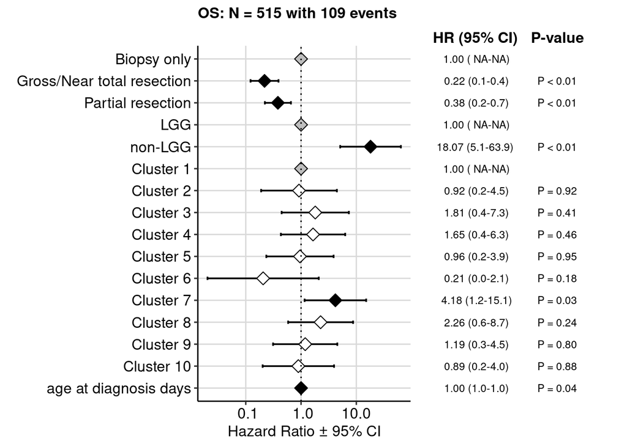

```r
add_model_os <- fit_save_model(metadata[!metadata$extent_of_tumor_resection %in% c(\Not Reported\, \Unavailable\),],
                              terms = \extent_of_tumor_resection+lgg_group+cluster+age_at_diagnosis_days\,
                               file.path(results_dir, \cox_OS_additive_terms_resection_lgg_group_cluster.RDS\),
                               \multivariate\,
                               years_col = \OS_years\,
                               status_col = \OS_status\)

forest_os <- plotForest(readRDS(file.path(results_dir, \cox_OS_additive_terms_resection_lgg_group_cluster.RDS\)))
```

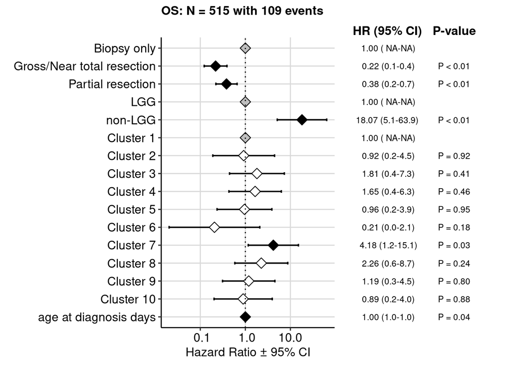

```r
forest_os
```

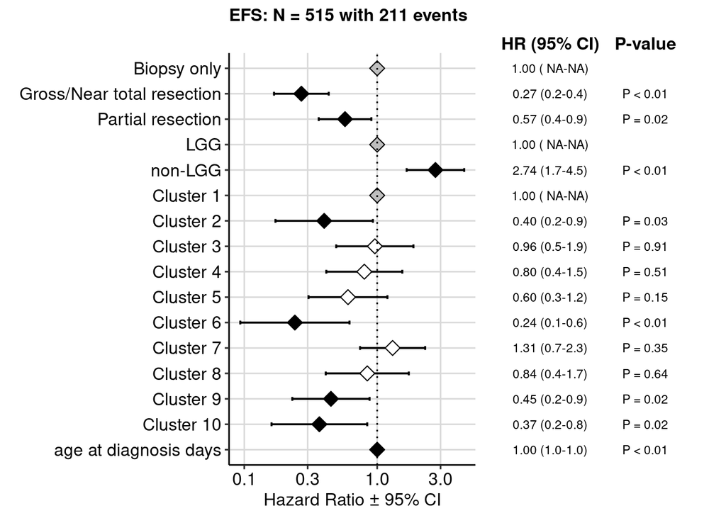

```r
ggsave(file.path(plot_dir, \forest_add_OS_resection_lgg_group_cluster_assignment.pdf\),
       forest_os,
       width = 10, height = 6, units = \in\,
       device = \pdf\)

add_model_efs <- fit_save_model(metadata[!metadata$extent_of_tumor_resection %in% c(\Not Reported\, \Unavailable\),],
                              terms = \extent_of_tumor_resection+lgg_group+cluster+age_at_diagnosis_days\,
                               file.path(results_dir, \cox_EFS_additive_terms_resection_lgg_group_cluster.RDS\),
                               \multivariate\,
                               years_col = \EFS_years\,
                               status_col = \EFS_status\)

forest_efs <- plotForest(readRDS(file.path(results_dir, \cox_EFS_additive_terms_resection_lgg_group_cluster.RDS\)))
```

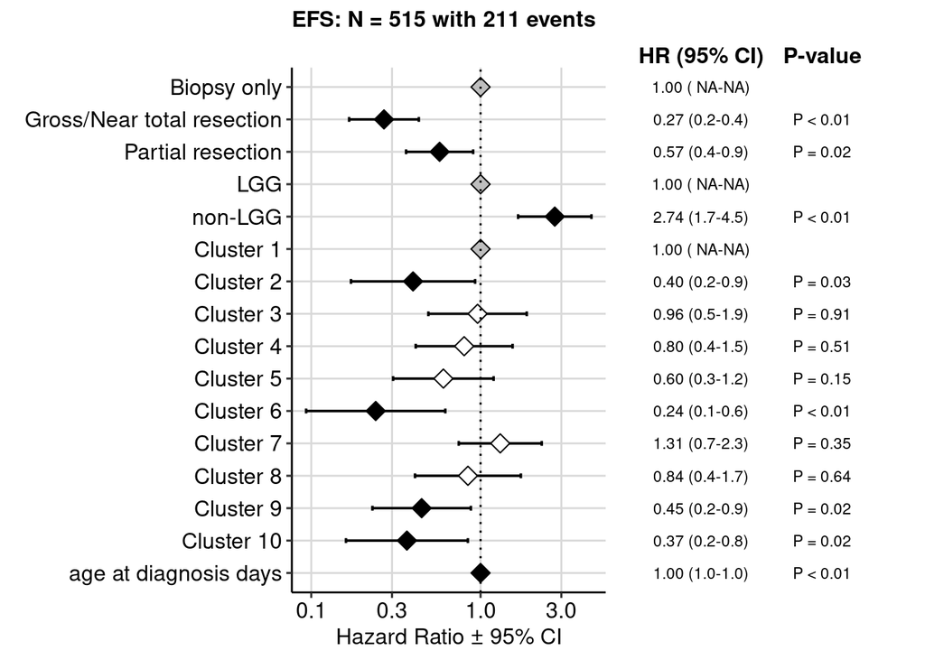

```r
forest_efs
```

```r
ggsave(file.path(plot_dir, \forest_add_EFS_resection_lgg_group_cluster_assignment.pdf\),
       forest_efs,
       width = 10, height = 6, units = \in\,
       device = \pdf\)
```

Subset `metadata` for LGG, and only include clusters with >= 10 samples

```r
lgg <- metadata %>%
  dplyr::filter(plot_group == \Low-grade glioma\) %>%
  dplyr::mutate(cluster = factor(cluster)) %>%
  dplyr::mutate(mol_sub_group = fct_relevel(mol_sub_group, c(\Wildtype\, \BRAF V600E\, \BRAF fusion\,
                                                                \Other alteration\, \SEGA\
                                                                )))

retain_clusters_lgg <- lgg %>%
  count(cluster) %>%
  filter(n >= 10) %>%
  pull(cluster)

lgg <- lgg %>%
  filter(cluster %in% retain_clusters_lgg) %>%
    dplyr::mutate(cluster = factor(cluster))
```

Generate log rank OS and EFS models with cluster assignment as predictor

```r
# Generate kaplan meier survival models for OS and EFS, and save outputs
lgg_kap_os <- survival_analysis(
  metadata  = lgg,
  ind_var = \cluster\,
  test = \kap.meier\,
  metadata_sample_col = \Kids_First_Biospecimen_ID\,
  days_col = \OS_days\,
  status_col = \OS_status\
)
readr::write_rds(lgg_kap_os,
                 file.path(results_dir, \logrank_lgg_OS_cluster_assignment.RDS\))

lgg_kap_efs <- survival_analysis(
  metadata  = lgg,
  ind_var = \cluster\,
  test = \kap.meier\,
  metadata_sample_col = \Kids_First_Biospecimen_ID\,
  days_col = \EFS_days\,
  status_col = \EFS_status\
)
readr::write_rds(lgg_kap_efs,
                 file.path(results_dir, \logrank_lgg_EFS_cluster_assignment.RDS\))
```

Generate LGG KM plots

```r
km_lgg_os_plot <- plotKM(model = lgg_kap_os,
                    variable = \cluster\,
                    combined = F,
                    title = \cluster\,
                    palette = cluster_cols[names(cluster_cols) %in% retain_clusters_lgg])
ggsave(file.path(plot_dir, \km_lgg_OS_cluster_assignment.pdf\),
       km_lgg_os_plot,
       width = 10, height = 6, units = \in\,
       device = \pdf\)
km_lgg_efs_plot <- plotKM(model = lgg_kap_efs,
                    variable = \cluster\,
                    combined = F,
                    title = \cluster\,
                    palette = cluster_cols[names(cluster_cols) %in% retain_clusters_lgg])
ggsave(file.path(plot_dir, \km_lgg_EFS_cluster_assignment.pdf\),
       km_lgg_efs_plot,
       width = 10, height = 6, units = \in\,
       device = \pdf\)
```

Generate coxph models including covariates `extent_of_tumor_resection`, `mol_sub_group`, and `cluster`, and plot

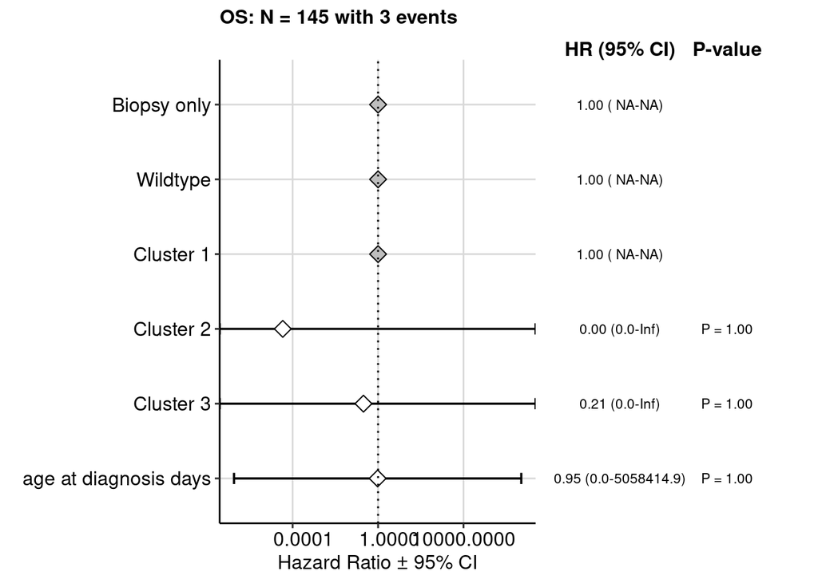

```r
add_model_lgg_os <- fit_save_model(lgg[!lgg$extent_of_tumor_resection %in% c(\Not Reported\, \Unavailable\),],
                              terms = \extent_of_tumor_resection+mol_sub_group+cluster+age_at_diagnosis_days\,
                               file.path(results_dir, \cox_lgg_OS_additive_terms_resection_subtype_cluster.RDS\),
                               \multivariate\,
                               years_col = \OS_years\,
                               status_col = \OS_status\)
forest_lgg_os <- plotForest(readRDS(file.path(results_dir, \cox_lgg_OS_additive_terms_resection_subtype_cluster.RDS\)))
```

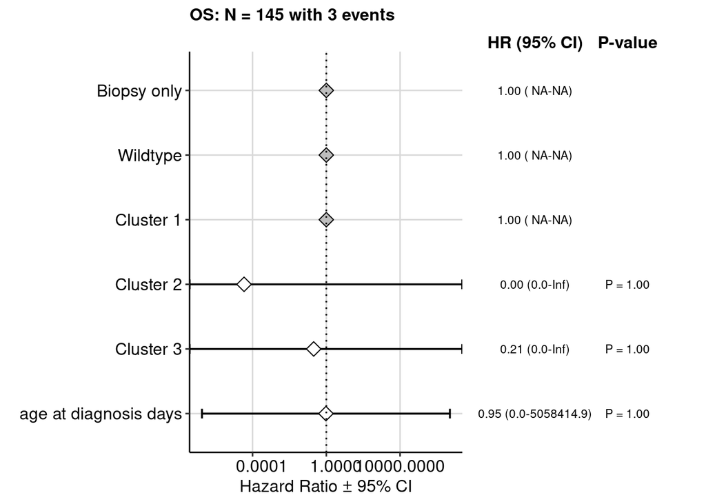

```r
forest_lgg_os
```

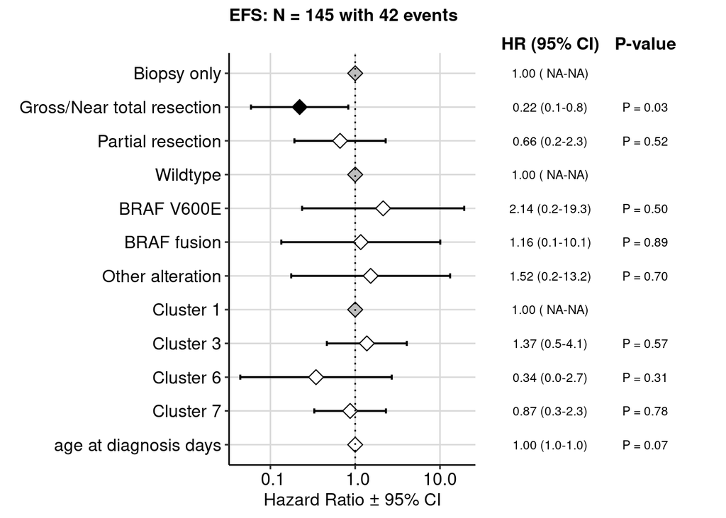

```r
ggsave(file.path(plot_dir, \forest_add_OS_LGG_resection_subtype_cluster_assignment.pdf\),
       forest_lgg_os,
       width = 10, height = 6, units = \in\,
       device = \pdf\)

# identify LGG clusters
lgg_clusters <- metadata %>%
  filter(lgg_group == \LGG\) %>%
  mutate(cluster = as.integer(gsub(\cluster\, \\, cluster))) %>%
  pull(cluster) %>%
  sort() %>%
  unique()
add_model_lgg_efs <- fit_save_model(lgg[!lgg$cluster %in% lgg_clusters & !lgg$extent_of_tumor_resection %in% c(\Not Reported\, \Unavailable\),],
                              terms = \extent_of_tumor_resection+mol_sub_group+cluster+age_at_diagnosis_days\,
                               file.path(results_dir, \cox_lgg_EFS_additive_terms_resection_subtype_cluster.RDS\),
                               \multivariate\,
                               years_col = \EFS_years\,
                               status_col = \EFS_status\)
forest_lgg_efs <- plotForest(readRDS(file.path(results_dir, \cox_lgg_EFS_additive_terms_resection_subtype_cluster.RDS\)))
```

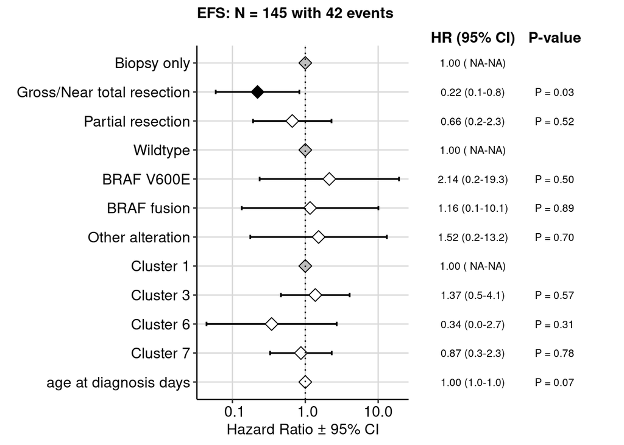

```r
forest_lgg_efs
```